# Dataiku

**Using ClearScape Analytics with Dataiku**

**Introduction**

Dataiku is the platform for Everyday AI, systemizing the use of data for exceptional business results. Organizations that use Dataiku elevate their people (whether technical and working in code or on the business side and low- or no-code) to extraordinary, arming them with the ability to make better day-to-day decisions with data. More than 450 companies worldwide use Dataiku to systemize their use of data and AI, driving diverse use cases from fraud detection to customer churn prevention, predictive maintenance to supply chain optimization, and everything in between.

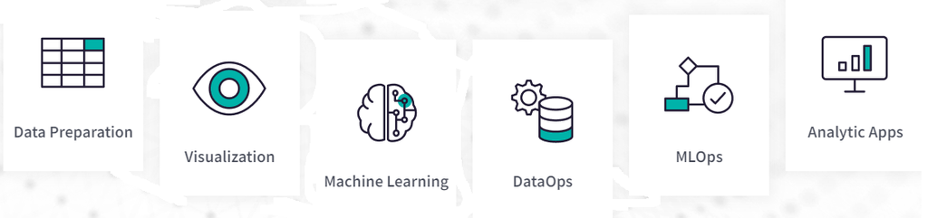

**Good News!!**

[figure not shown]

**Video Demonstration ...**

Click on the Play Button below to see a demonstration of the two working together.

```python
%%HTML
<iframe width="640" height="480" src="https://teradata.seismic.com/app?ContentId=ed00dc98-6527-43fa-a988-c57bfb254b22#/doccenter/dc7eb2cf-bd2e-462a-a056-fcc02c9fd2f2/doc/%252Fddc59ac087-0ac6-cce5-2000-79263b79ee73%252FdfYmI3ODY3ZDQtM2Q4Zi00ZTk5LTg2ZDYtNjBlZTk4ODY2YTY4%252CPT0%253D%252CRW1wbG95ZWVzICYgQXBwcm92ZWQgQXNzb2NpYXRlcw%253D%253D%252FdfODEyNmNlZmEtZmM4Mi00ODUyLTgzZTAtOTEzMTBlODQ5YjUw%252CPT0%253D%252CVmlkZW8%253D%252Flf30b1c339-c5a9-456d-8d56-f5757c614e04/grid/" allowfullscreen style="border:none;"></iframe>
```

[interactive chart not shown]

**How to Setup Dataiku**